# ECE Industrial Advisory Board Meeting 2026

Prof. Abhishek Gupta — Chair, Graduate Studies

**Department of Electrical & Computer Engineering**  
The Ohio State University

November 12, 2026

## ECE@OSU Graduate Studies Team

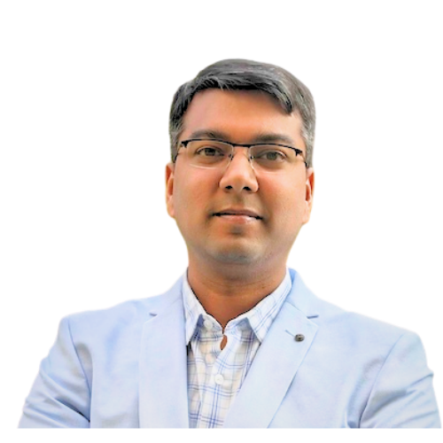

Prof. Abhishek Gupta  
Chair, Graduate Studies · Dreese Lab 464  
gupta.706@osu.edu

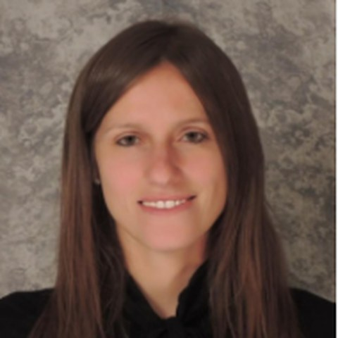

Prof. Lisa Fiorentini  
Chair, Graduate Admissions · MS Advisor  
fiorentini.2@osu.edu

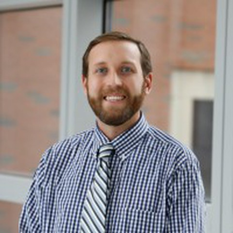

Tim Langreder  
PhD Program Coordinator · Dreese Lab 236  
langreder.1@osu.edu

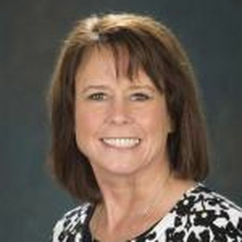

Beth Bucher  
MS Program Coordinator · Dreese Lab 238  
bucher.9@osu.edu

## Six research areas — and their chairs

| Research area | Area chair |
| --- | --- |
| Solid-State Electronics & Photonics | Prof. Wu Lu |
| Power & Energy | Prof. Mahesh Illindala |
| Control, Signal / Image Processing & Computer Vision | Prof. Zak Kassas |
| Electromagnetics | Prof. Asimina Kiourti |
| Circuits | Prof. Tawfiq Musah |
| Computer Engineering, Networks & Communications | Prof. Can E. Koksal |

# MS and PhD Programs and Certifications

## Two degrees, three paths

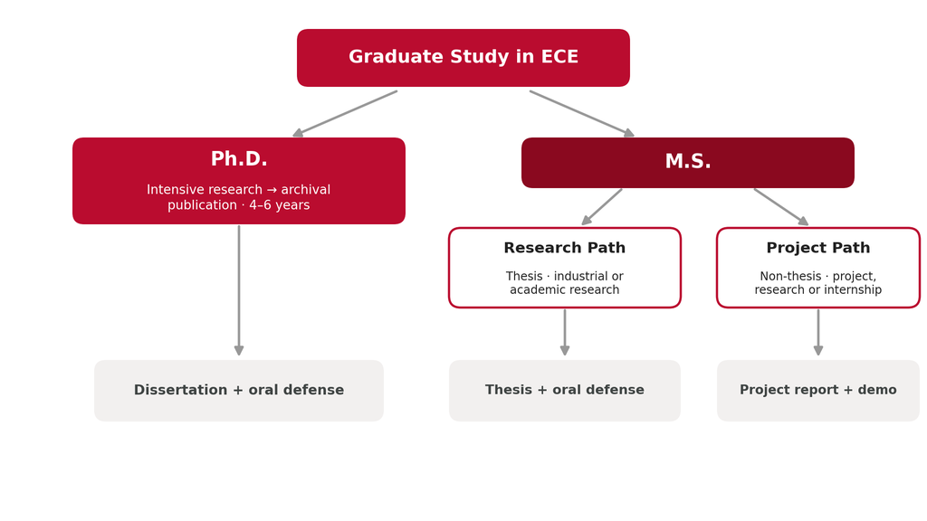

Graduate courses are demanding – complex homeworks, difficult exams, sophisticated projects.

## PhD vs. MS program overview

Key differences in research depth, coursework timeline, and degree expectations.

PhD Program (~5 years)

- **Goal:** Conduct intensive and prolonged research on a specialized topic, leading to **archival publication** and **scientific or engineering breakthroughs**
- **Years 1–3:** Coursework to fulfill degree requirements & broaden technical foundation
- **Years 1–5+:** Focus on original **research & final dissertation**

MS Program (~3-4 semesters)

- **Goal:** Develop expertise in a specialized field of ECE
- **Semesters 1–2:** Coursework to fulfill degree requirements
- **Semesters 3–4:** Focus on advanced courses and **project / thesis**
- Allow at least 2 semesters to complete the project and 3+ for thesis

## Degree Requirements

### PhD (post BS)

| Requirement | Credits | Details |
| --- | --- | --- |
| Dissertation Research — ECE 8999 | 50 min | — |
| Letter-graded graduate courses *(5000+ / 6000+)* | 28 min | 21 cr ECE letter-graded · ≥2 ECE 6xxx · ≤9 cr related field |
| Engineering Ethics — PHILOS or ECE 7080 | 1 | Waived if you completed ECE 3080 or PHILOS 1332 |
| Individual Studies — ECE 8193 | ≤2 | — |
| Seminar — ECE 8891 | 2 | Attend ≥3 seminars per enrolled semester |

### MS (non-thesis)

| Requirement | Credits | Details |
| --- | --- | --- |
| Letter-graded graduate courses | 24 min | ECE graduate ≥15 · advanced ECE ≥6 · **ECE 6070 Project Management** (first 2 semesters) · related ≤9 |
| Engineering Ethics — PHILOS or ECE 7080 | 1 | Waived if you completed ECE 3080 or PHILOS 1332 |
| Individual Studies — ECE 6193 | ≤5 | — |
| MS Non-Thesis Exam | Project | 1-page proposal → advisor approval, then a project report |

PhD after MS needs 50 credits, MS with thesis is done under a faculty

## New Minors and Certifications

### Undergraduate

Embedded certificates & Minor

- Signal Processing
- Semiconductor Devices
- Tech Entrepreneurship
- Robotics

### Graduate

Embedded for students. Stand-alone for professionals.

- Semiconductor Optoelectronics
- Semiconductor Devices
- Semiconductor Fabrication Technology
- Cybersecurity

## ECE Graduate Ranking remains in mid-20s

[figure not shown]

Sources · U.S. News national rank, Ohio State announcements

[2018 · news.osu.edu/11-ohio-state-graduate-programs-ranked-in-top-10](https://news.osu.edu/11-ohio-state-graduate-programs-ranked-in-top-10-by-us-news--world-report/)

[2019 · engineering.osu.edu/news/2018/03/engineering-grad-programs-rank-among-nations-best](https://engineering.osu.edu/news/2018/03/engineering-grad-programs-rank-among-nations-best)

[2020 · engineering.osu.edu/news/2019/03/grad-program-ranked-14th-among-publics](https://engineering.osu.edu/news/2019/03/grad-program-ranked-14th-among-publics) · [ECE](https://ece.osu.edu/news/2020/03/ece-graduate-program-jumps-22-2021-u.s.-news-and-world-report-rankings)

[2021 · ece.osu.edu/news/2020/03/ece-graduate-program-jumps-22](https://ece.osu.edu/news/2020/03/ece-graduate-program-jumps-22-2021-u.s.-news-and-world-report-rankings) · [college](https://engineering.osu.edu/news/2020/03/grad-programs-rank-among-best-nation)

[2022 · engineering.osu.edu/news/2021/03/ohio-state-engineering-grad-programs-rank-among-best-us](https://engineering.osu.edu/news/2021/03/ohio-state-engineering-grad-programs-rank-among-best-us)

[2023 · engineering.osu.edu/news/2022/03/graduate-programs-rank-among-nations-best](https://engineering.osu.edu/news/2022/03/graduate-programs-rank-among-nations-best)

[2024 · engineering.osu.edu/news/2023/04/graduate-program-rankings-rise](https://engineering.osu.edu/news/2023/04/graduate-program-rankings-rise)

[2025 · engineering.osu.edu/news/2024/06/graduate-program-jumps-13th-among-publics](https://engineering.osu.edu/news/2024/06/graduate-program-jumps-13th-among-publics)

[2026 · engineering.osu.edu/news/2025/04/graduate-program-ranks-13th-among-publics](https://engineering.osu.edu/news/2025/04/graduate-program-ranks-13th-among-publics)

[2027 · engineering.osu.edu/news/2026/04/graduate-program-ranks-14th-among-publics](https://engineering.osu.edu/news/2026/04/graduate-program-ranks-14th-among-publics)

## IITB–OSU Cotutelle (joint PhD) program

Years 1–2 IIT Bombay Coursework and the qualifying exam. IITB pays the stipend.

Year 2 The match An OSU advisor selects the student, who applies through the regular process.

Years 3–5 Ohio State 1–2 years on the joint project in Columbus. The OSU co-advisor pays the GRA only then.

Graduation Two Ph.D. degrees A joint committee of three faculty from each university.

OSU faculty

Fund 1–2 years instead of five. The student arrives trained, already on your project, and you advise the OSU degree to completion.

IITB faculty

Your student stays enrolled at IITB the whole way. You co-advise the Columbus years, which OSU funds, and share the papers.

## Research expenditures (~30% F&A)

[figure not shown]

# Enrollment Trends

## ECE@OSU Graduate Admissions recovered, still mid-pack

[figure not shown]

## MS applications fell, then stabilized

[figure not shown]

## Applications for PhD admissions are recovering

### Remains an attractive option for immigration

[figure not shown]

## MS applications against the U.S. trend

### Ohio State ECE, and all engineering fields nationally

[figure not shown]

Table B.2, Engineering applications, CGS/GRE Survey of Graduate Enrollment and Degrees

[Fall 2019](https://web.archive.org/web/20201101134115id_/https://cgsnet.org/ckfinder/userfiles/files/CGS_GED19_Report_final2.pdf) · [Fall 2020](https://cgsnet.org/wp-content/uploads/2022/02/CGS_GED20_Report_Apx-B.pdf) · [Fall 2021](https://cgsnet.org/wp-content/uploads/2022/11/CGS_GED21_Report_v1-1.pdf) · [Fall 2022](https://cgsnet.org/wp-content/uploads/2023/10/2022-Graduate-Enrollment-and-Degrees-Tables-and-Appendices.pdf) · [Fall 2023](https://cgsnet.org/wp-content/uploads/2024/12/GED-Tables-2024-1.2.pdf) · [Fall 2024](https://cgsnet.org/wp-content/uploads/2025/12/CGS_GED-2025_Appendices-A-E_Final.pdf)

## PhD applications against the U.S. trend

### Ohio State ECE, and all engineering fields nationally

[figure not shown]

Table B.2, Engineering applications, CGS/GRE Survey of Graduate Enrollment and Degrees

[Fall 2019](https://web.archive.org/web/20201101134115id_/https://cgsnet.org/ckfinder/userfiles/files/CGS_GED19_Report_final2.pdf) · [Fall 2020](https://cgsnet.org/wp-content/uploads/2022/02/CGS_GED20_Report_Apx-B.pdf) · [Fall 2021](https://cgsnet.org/wp-content/uploads/2022/11/CGS_GED21_Report_v1-1.pdf) · [Fall 2022](https://cgsnet.org/wp-content/uploads/2023/10/2022-Graduate-Enrollment-and-Degrees-Tables-and-Appendices.pdf) · [Fall 2023](https://cgsnet.org/wp-content/uploads/2024/12/GED-Tables-2024-1.2.pdf) · [Fall 2024](https://cgsnet.org/wp-content/uploads/2025/12/CGS_GED-2025_Appendices-A-E_Final.pdf)

## U.S. Graduate Engineering enrollment

[figure not shown]

Table B.9, Engineering first-time enrollment, CGS/GRE Survey of Graduate Enrollment and Degrees. International students are temporary residents in the table.

[Fall 2019](https://web.archive.org/web/20201101134115id_/https://cgsnet.org/ckfinder/userfiles/files/CGS_GED19_Report_final2.pdf) · [Fall 2020](https://cgsnet.org/wp-content/uploads/2022/02/CGS_GED20_Report_Apx-B.pdf) · [Fall 2021](https://cgsnet.org/wp-content/uploads/2022/11/CGS_GED21_Report_v1-1.pdf) · [Fall 2022](https://cgsnet.org/wp-content/uploads/2023/10/2022-Graduate-Enrollment-and-Degrees-Tables-and-Appendices.pdf) · [Fall 2023](https://cgsnet.org/wp-content/uploads/2024/12/GED-Tables-2024-1.2.pdf) · [Fall 2024](https://cgsnet.org/wp-content/uploads/2025/12/CGS_GED-2025_Appendices-A-E_Final.pdf)

## Graduate certificates are just starting

[figure not shown]

## BS-MS program @ ECE OSU

[figure not shown]

# International vs Domestic Trends

## International Students stopped applying for MS

### Partly due to GDP growth in their own countries

[figure not shown]

## International MS enrollment fell in 2025

### Visa + jobs challenges

[figure not shown]

## International PhD applications are recovering

### Low enrollment due to lack of funding

[figure not shown]

## Domestic PhD enrollment has declined

### Graduate education is a net negative ROI for top domestic students

[figure not shown]

# Challenges and the Road Ahead

## Headwinds and Impact

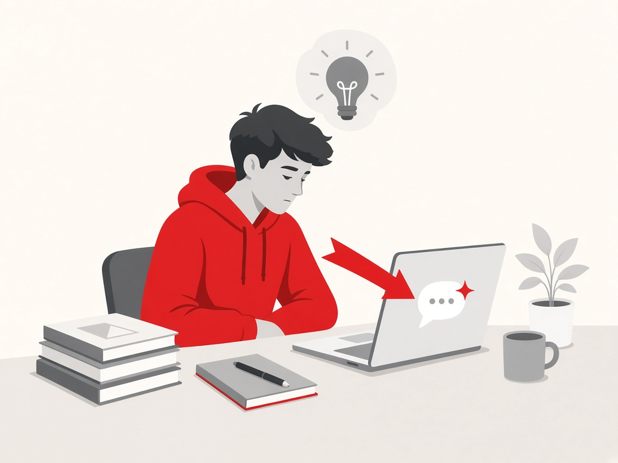

AI skips the learning, creating bimodal distribution in the class

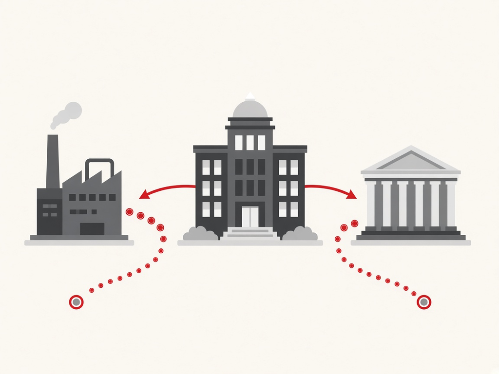

Research funding pulls away, new unusual partnerships needed to win grants

## Tailwinds

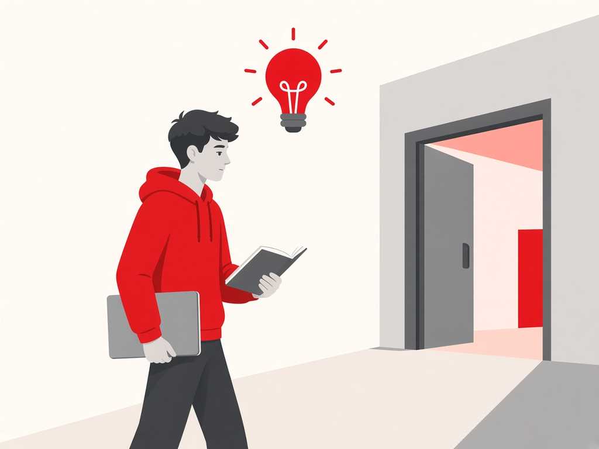

AI fluency opens the door for capable students, attracting them towards our graduate program

[figure not shown]

Continued interest in PhD from international students

## New Pathway: Practical PhD?

Traditionally, PhDs were granted for fundamental discoveries and inventions, which would proliferate in the market in 10-20 years. But should that change in 2026? Can we have joint PhD between industry and academia?

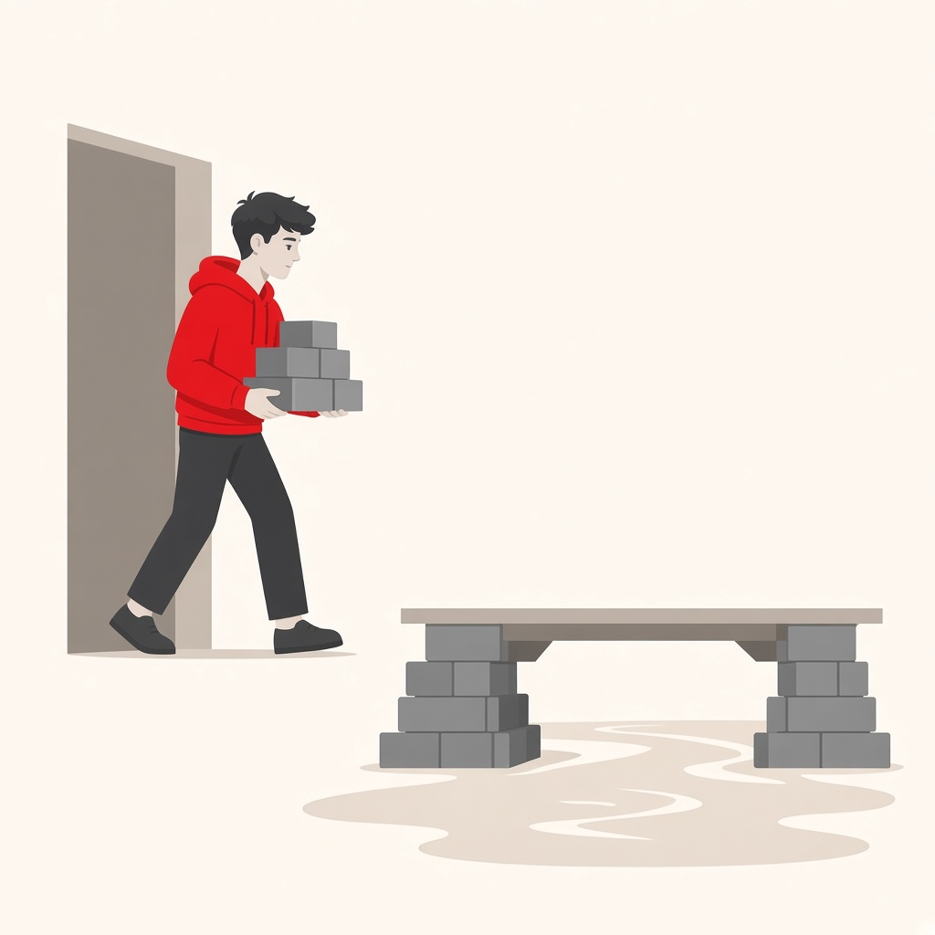

Goal · Build new products that find immediate use in industry

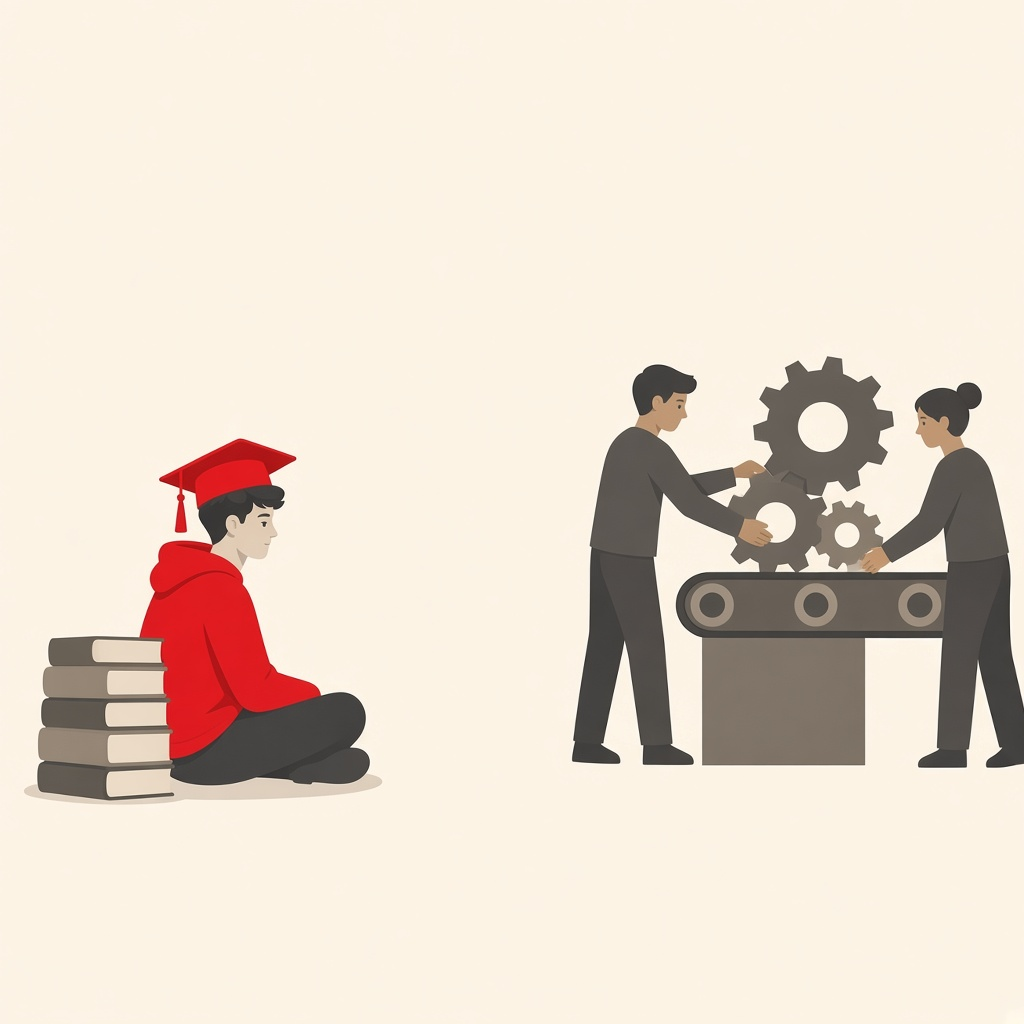

Benefit · Solve real-life problems that carry strategic importance

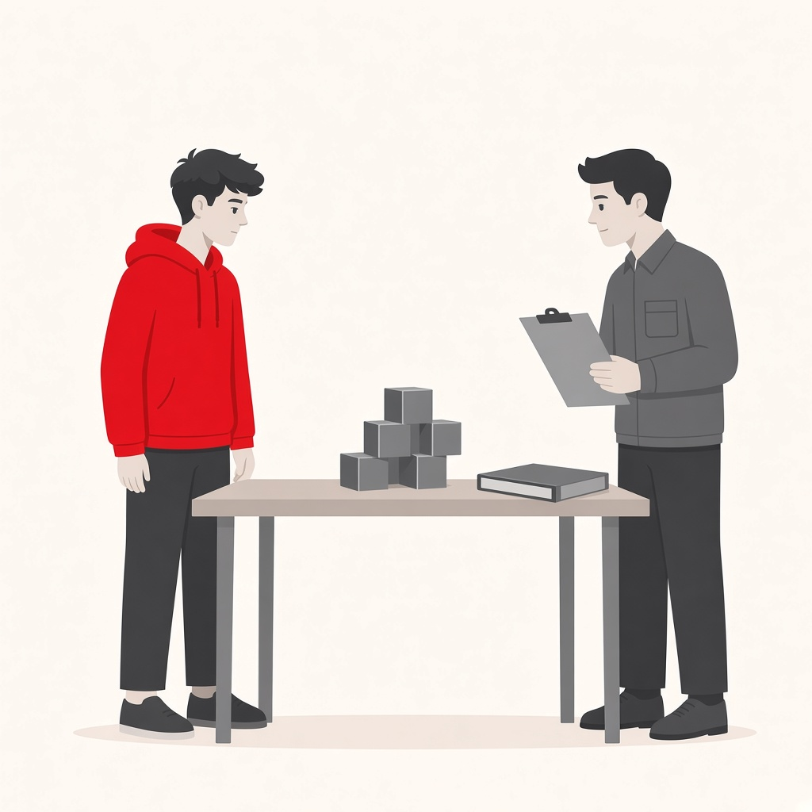

Challenge · Novel product is hard to grade

[First ‘practical PhDs’ awarded in China — for products rather than papers](https://www.nature.com/articles/d41586-026-00356-8)

## Faculty entrepreneurship: Three gaps that seem impossible to fill

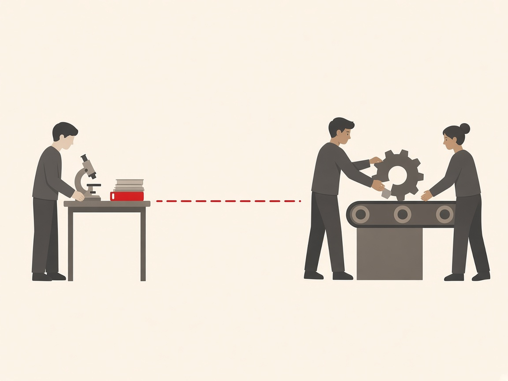

Lack of knowledge of productization of research

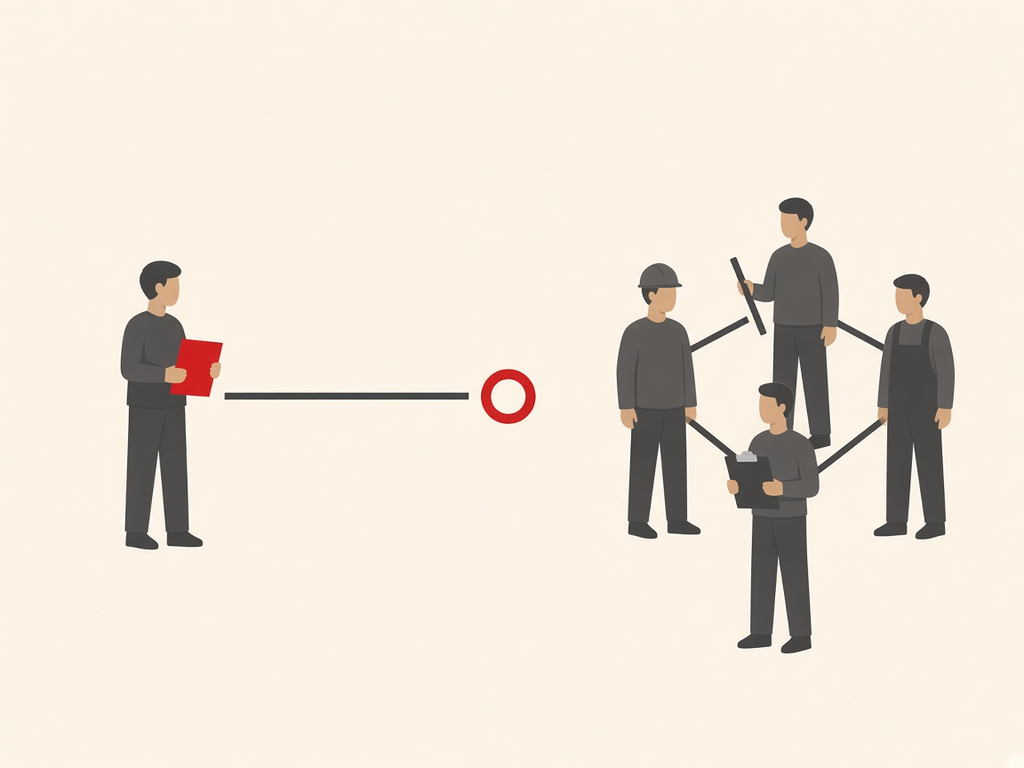

Thin Connections to people with deep domain knowledge

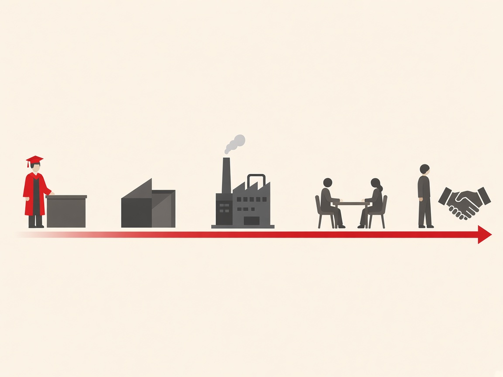

No prior experience with customer interviews and long sale cycles

[BuildX initiative set to help Ohio State student founders launch startups](https://engineering.osu.edu/news/2026/09/buildx-initiative-set-help-ohio-state-student-founders-launch-startups) — spring 2027 startup labs, a summer accelerator with $15,000 and founder coaching in Pomerene Hall, and a $1 million fund, alongside the Keenan Center

## Goals for the future

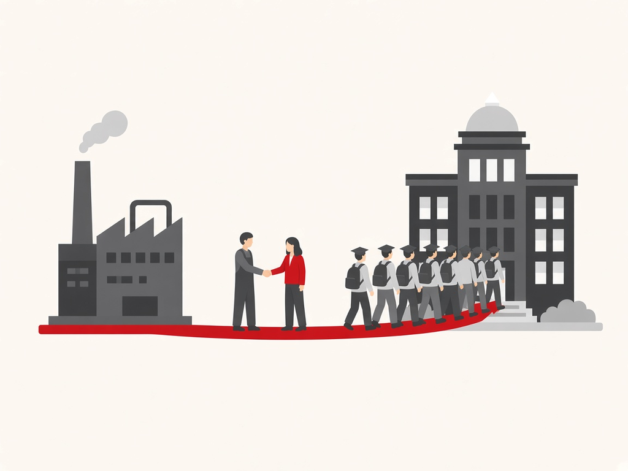

Research partnerships: Access to pain points and premium money ($100k per student year)

[figure not shown]

Online MS for underserved & high demand topics

## What we need for OSU MS and PhD graduates

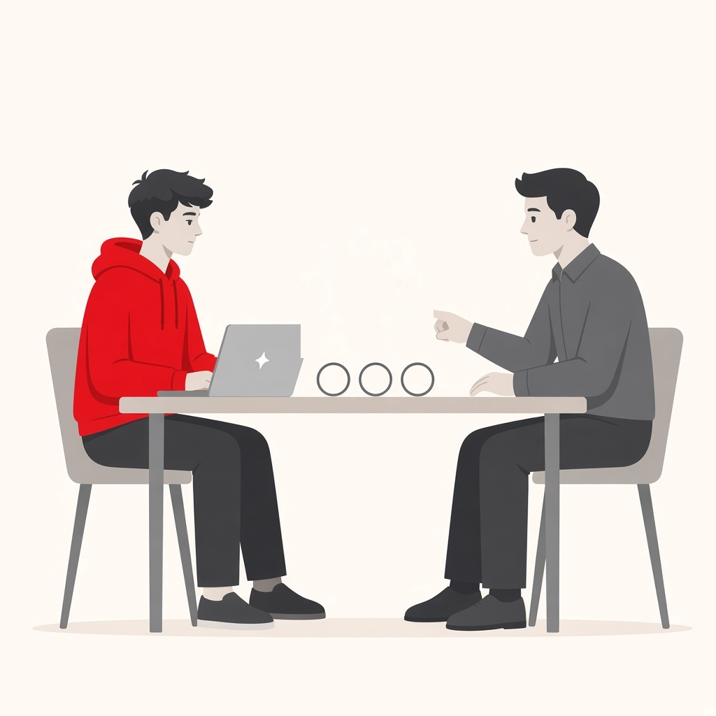

Where to set the AI bar for the next generation of workforce

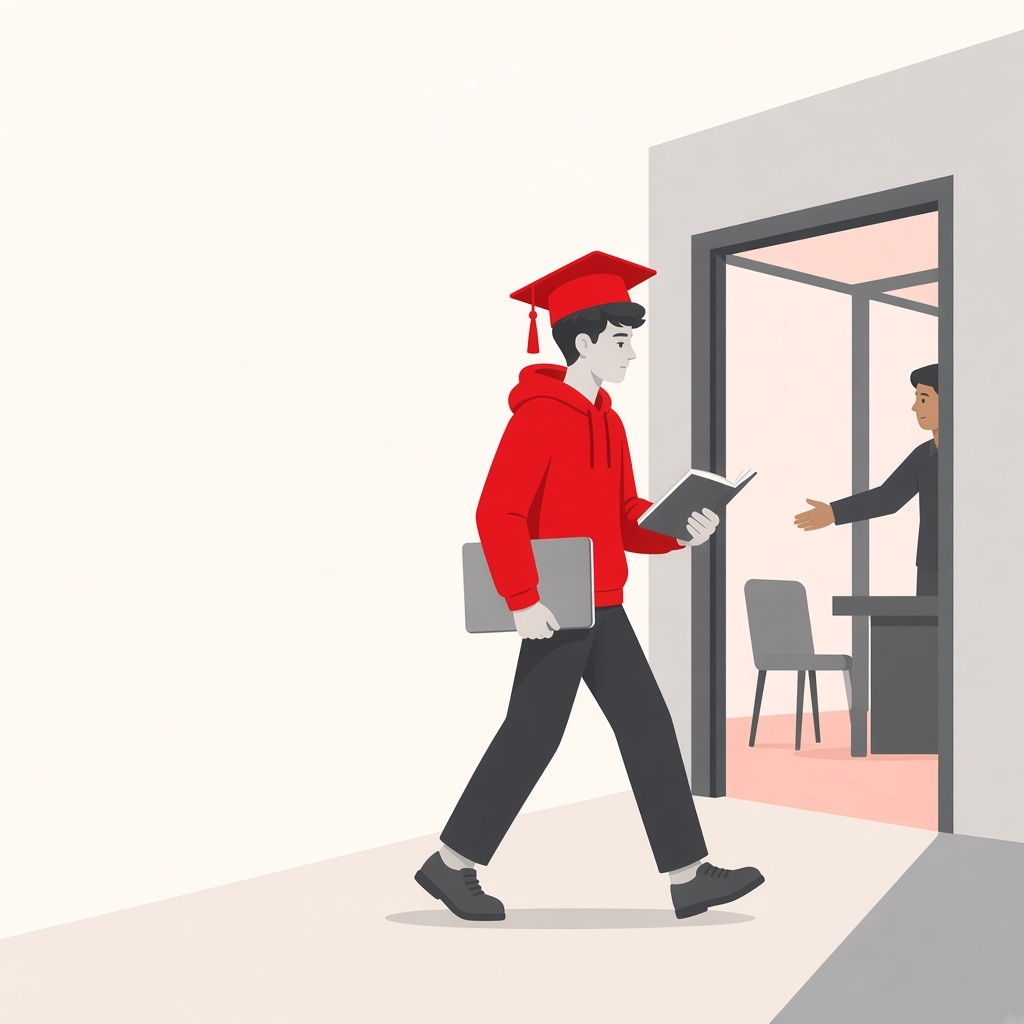

Reduce job risk by creating pathways for hiring, coop, internships

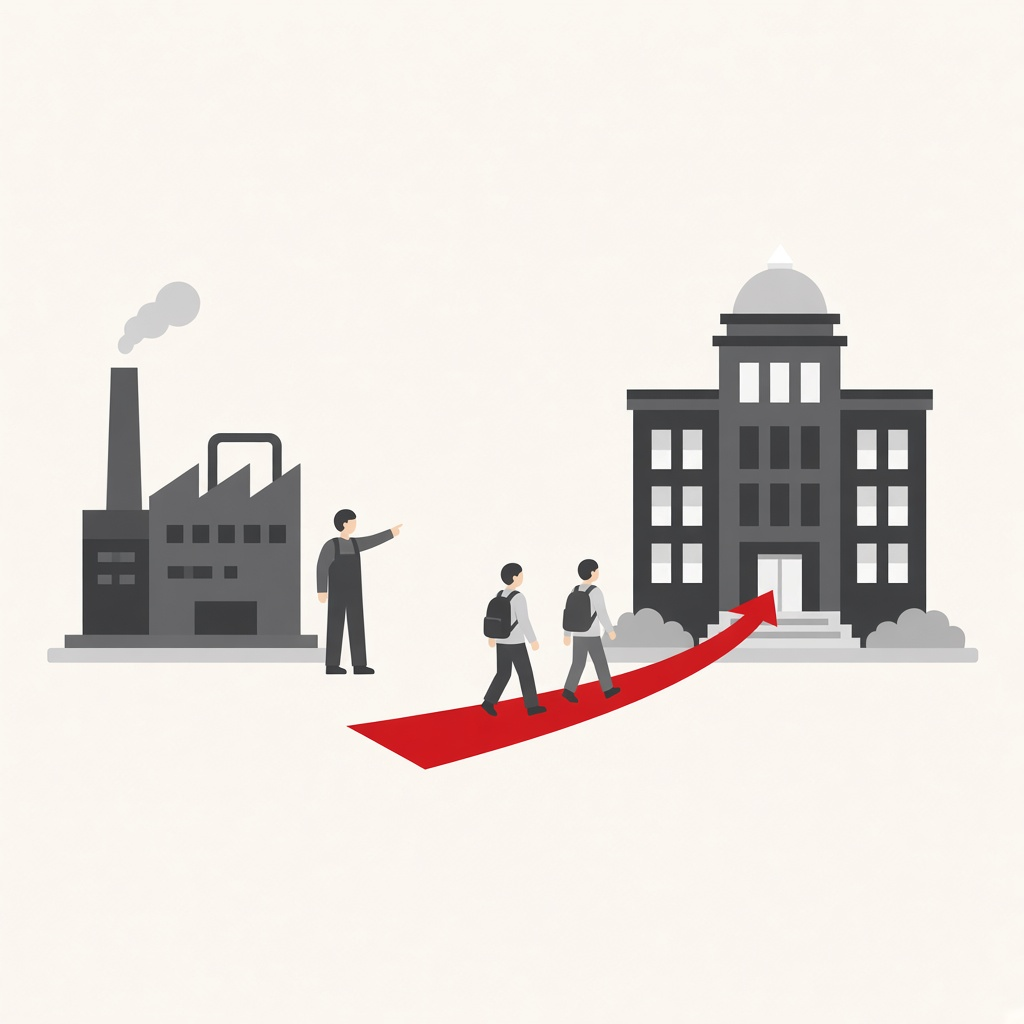

Online education = Sustained topics + Differentiation + Outreach Plan + Volume